# Natural Experiments

Abishan Arumugavel and Daniel Beeler

2025-02-23

# Analysis of variables correlating with the home win percentage in the English Premier League

## Introduction

In this analysis, we aim to investigate the factors that correlate with the home win percentage in the English Premier League. We will explore various variables such as attendance, goal difference, and win/loss streaks to understand their impact on the likelihood of a home team winning a match. By analyzing historical data from the Premier League, we can gain insights into the key drivers of home team success and identify patterns that may influence match outcomes.

## Importing Data

Here we import the relevant dataset into our project.

```r
library(readr)
library(readxl)

# Premier League data from 2006 to 2018
data <- read.csv("results.csv")

# Attendance rates from 2006 to 2018
attendance <- read_excel("Attendance.xlsx")

# Premier League data of the 2024 season
# We us additionaly this dataset, because this data set has more information concerning each match of the season.
premier_league_2024 = read.csv("premier league.csv")
```

## Data Cleaning

Here we clean the data, and add relevant columns, which we need for our further analysis.

```r
# Calculate goal difference
data$goal_difference <- data$home_goals - data$away_goals

# Calculate points for the home team (3 points for win, 1 point for a draw, 0 points for a loss)
data$points_home <- ifelse(data$result == "H", 3, ifelse(data$result == "D", 1, 0))

# Calculate points for the away team (3 points for win, 1 point for a draw, 0 points for a loss)
data$points_away <- ifelse(data$result == "A", 3, ifelse(data$result == "D", 1, 0))

library(dplyr)
attendance <- attendance %>%
  rename(
    season = Saison,
    team = Team,
    average_attendance = `Average Attendance`
  )

data <- data %>%
  left_join(attendance,
            by = c("season" = "season",
                   "home_team" = "team")) %>%
  rename(home_average_attendance = average_attendance)
```

## Analysis

### Analysis of win and loss streaks on the wining probability of a team

We have decided to conduct an analysis on the Premier League data for the 2024 season. We will be looking at the performance of each teams and their opponents in terms of win and loss streaks. This analysis will help us understand the momentum of the teams and how it might affect the outcome of future matches. We will also investigate the impact of the venue (home or away) on the team’s performance.

Here for we used the data set only from the season 2024, because this was the only dataset we found with the necessary information.

```r
# Sort the data by date
premier_league <- premier_league_2024[order(premier_league_2024$Date),]
head(premier_league)
```

```
##     X       Date  Time           Comp       Round Day Venue Result GF GA
## 1   1 2023-08-11 20:00 Premier League Matchweek 1 Fri  Away      W  3  0
## 685 0 2023-08-11 20:00 Premier League Matchweek 1 Fri  Home      L  0  3
## 39  1 2023-08-12 12:30 Premier League Matchweek 1 Sat  Home      W  2  1
## 115 0 2023-08-12 17:30 Premier League Matchweek 1 Sat  Away      L  1  5
## 229 0 2023-08-12 17:30 Premier League Matchweek 1 Sat  Home      W  5  1
## 305 0 2023-08-12 15:00 Premier League Matchweek 1 Sat  Away      D  1  1
##            Opponent  xG xGA Poss Attendance         Captain Formation
## 1           Burnley 1.9 0.3   65      21572 Kevin De Bruyne   4-2-3-1
## 685 Manchester City 0.3 1.9   35      21572     Josh Cullen     5-4-1
## 39  Nott'ham Forest 0.8 1.2   78      59984 Martin Ødegaard     4-3-3
## 115   Newcastle Utd 1.8 3.3   48      52207     John McGinn   4-2-3-1
## 229     Aston Villa 3.3 1.8   52      52207 Kieran Trippier     4-3-3
## 305     Bournemouth 1.1 1.3   38      11245      Kurt Zouma   4-2-3-1
##            Referee Match.Report Notes Sh SoT Dist FK PK PKatt Season
## 1     Craig Pawson Match Report    NA 17   8 13.9  0  0     0   2024
## 685   Craig Pawson Match Report    NA  6   1 14.9  0  0     0   2024
## 39  Michael Oliver Match Report    NA 15   7 19.1  0  0     0   2024
## 115    Andy Madley Match Report    NA 16   6 14.5  1  0     0   2024
## 229    Andy Madley Match Report    NA 17  12 13.2  0  0     0   2024
## 305   Peter Bankes Match Report    NA 16   2 16.1  0  0     0   2024
##                Team
## 1    ManchesterCity
## 685         Burnley
## 39          Arsenal
## 115      AstonVilla
## 229 NewcastleUnited
## 305   WestHamUnited
```

```r
# Load required libraries
library(tidyr)
library(stats)
library(ggplot2)
library(gridExtra)
# Create team results dataframe
team_results <- premier_league %>%
  select(Date, Team, Opponent, Result, Venue) %>%
  mutate(Date = as.Date(Date))

# Create opponent results dataframe with flipped outcomes
# Here we need to also take in account that when one team wins, the other team loses and vice versa.
opponent_results <- premier_league %>%
  select(Date, Team, Opponent, Result, Venue) %>%
  mutate(
    Result = case_when(
      Result == "W" ~ "L",
      Result == "L" ~ "W",
      Result == "D" ~ "D"
    ),
    temp = Team,
    Team = Opponent,
    Opponent = temp,
    # The same goes for the venue, if one team plays at home, the other team plays away.
    Venue = ifelse(Venue == "Home", "Away", "Home"),
    Date = as.Date(Date)
  ) %>%
  select(-temp)

# Combine and calculate streaks
all_results <- rbind(team_results, opponent_results) %>%
  arrange(Date, Team) %>%
  group_by(Team) %>%
  arrange(Date) %>%
  mutate(
    win_streak = cumsum(Result == "W") - cumsum(Result != "W" & lag(Result == "W", default = FALSE)),
    lose_streak = cumsum(Result == "L") - cumsum(Result != "L" & lag(Result == "L", default = FALSE))
  ) %>%
  ungroup()

# Prepare modeling data
model_data <- all_results %>%
  mutate(
    win = ifelse(Result == "W", 1, 0),
    is_home = ifelse(Venue == "Home", 1, 0)
  ) %>%
  select(win, is_home, win_streak, lose_streak)
```

Although win is a binary outcome (0/1), we are here treating it with a linear model to get a quick and interpretable assessment of how these factors correlate with the team’s chance of winning. This model allows us to estimate a continuous outcome (predicted win probability) on a 0–1 scale, even though a logistic regression might be more common for binary data. Nonetheless, the linear approach is acceptable for exploratory analysis or illustrative purposes.

Our linear model is of the form:
$$\hat{y} = \beta_0
+ \beta_1 \cdot \texttt{is_home}
+ \beta_2 \cdot \texttt{win_streak}
+ \beta_3 \cdot \texttt{lose_streak}$$

where:

- $\hat{y}$ s the predicted value of win (interpreted here as a proxy for the probability of winning).
- $\beta_0$ is the intercept (baseline outcome when all predictors are zero).
- $\beta_1$, $\beta_2$, and $\beta_3$ are the coefficients for the home venue, the current win streak, and the current loss streak, respectively.

```r
# Fit linear regression model
model <- lm(win ~ is_home + win_streak + lose_streak, data = model_data)

# Print results
print(summary(model))
```

```
##
## Call:
## lm(formula = win ~ is_home + win_streak + lose_streak, data = model_data)
##
## Residuals:
##     Min      1Q  Median      3Q     Max
## -1.0391 -0.3613 -0.2251  0.5087  1.0975
##
## Coefficients:
##              Estimate Std. Error t value Pr(>|t|)
## (Intercept)  0.299387   0.021108  14.184  < 2e-16 ***
## is_home      0.131108   0.023176   5.657 1.84e-08 ***
## win_streak   0.018663   0.001468  12.715  < 2e-16 ***
## lose_streak -0.014855   0.001592  -9.330  < 2e-16 ***
## ---
## Signif. codes:  0 '***' 0.001 '**' 0.01 '*' 0.05 '.' 0.1 ' ' 1
##
## Residual standard error: 0.4517 on 1516 degrees of freedom
## Multiple R-squared:  0.1463, Adjusted R-squared:  0.1446
## F-statistic: 86.62 on 3 and 1516 DF,  p-value: < 2.2e-16
```

#### Model Summary Interpretation

- **Intercept** ($\beta_0$ ≈ 0.299387)
  - This indicates the model’s baseline prediction when is_home = 0, win_streak = 0, and lose_streak = 0. A value of 0.299 suggests that, in the absence of other effects, a team has a predicted win rate (or probability) of about 29.9%.
- **is_home** ($\beta_1$ ≈ 0.131108)
  - A positive coefficient indicates that playing at home is associated with a higher likelihood of winning. Holding all else constant, being the home team increases the predicted win value by approximately 0.131. This effect is both positive and statistically significant (𝑝 < 0.001).
- **win_streak** ($\beta_2$ ≈ 0.018663)
  - This coefficient suggests that for each additional game in the current winning streak, the predicted win probability increases by about 0.019. This effect is also highly significant (𝑝 < 0.001), which aligns with the idea that teams on a winning streak tend to continue winning.
- **lose_streak** ($\beta_3$ ≈ -0.014855)
  - A negative coefficient implies that for each additional game in the current losing streak, the predicted win probability decreases by about 0.015. This is likewise statistically significant (𝑝 < 0.001) and suggests that teams on a losing streak are somewhat less likely to win their next match.

**Model Fit:** - **Multiple R-squared** = 0.1463 (Adjusted R-squared: 0.1446) * About 14.6% of the variation in the win variable is explained by these three predictors. While this indicates that the model leaves a good deal of variation unexplained (which is common in sports outcomes), the predictors do have a meaningful, statistically significant relationship with winning.

```r
# Calculate correlation matrix
correlation_matrix <- cor(model_data)

# Print correlation matrix
print(correlation_matrix)
```

```
##                    win      is_home  win_streak lose_streak
## win          1.0000000  0.140143908 0.279395262 -0.19151922
## is_home      0.1401439  1.000000000 0.004969552 -0.01958263
## win_streak   0.2793953  0.004969552 1.000000000  0.11180061
## lose_streak -0.1915192 -0.019582629 0.111800612  1.00000000
```

### Conclusion of the first Analysis

From this linear model, we see that venue (is_home), win streak, and lose streak each play an important role in predicting the likelihood of winning a match. The positive and negative coefficients for these predictors make intuitive sense: - **Home Advantage** – Slight increase in win probability. - **Winning Momentum** – Each consecutive win boosts chances for the next match. - **Losing Momentum** – Each consecutive loss decreases chances for the next match.

Although the model explains only a modest portion of the variance in outcomes, it provides useful insights into how these factors correlate with a team’s probability of winning.

#### Visualization

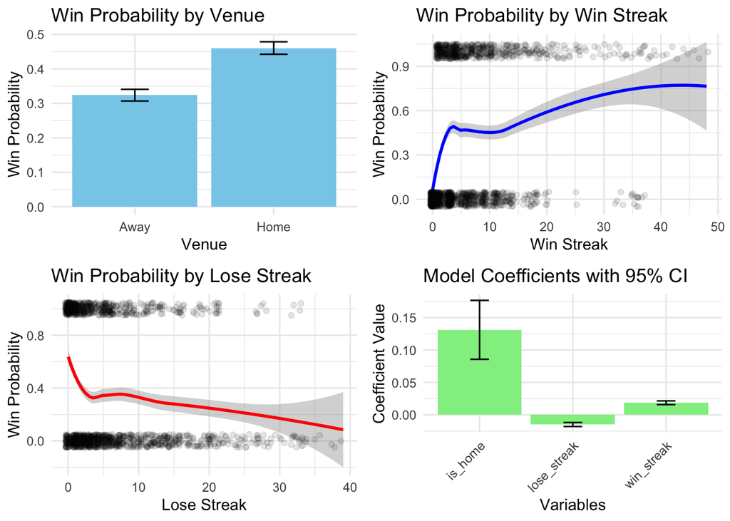

```r
# Create visualization plots
venue_plot <- ggplot(model_data, aes(x = factor(is_home), y = win)) +
  geom_bar(stat = "summary", fun = "mean", fill = "skyblue") +
  geom_errorbar(stat = "summary", fun.data = "mean_se", width = 0.2) +
  scale_x_discrete(labels = c("Away", "Home")) +
  labs(x = "Venue", y = "Win Probability", title = "Win Probability by Venue") +
  theme_minimal()

win_streak_plot <- ggplot(model_data, aes(x = win_streak, y = win)) +
  geom_smooth(method = "loess", se = TRUE, color = "blue") +
  geom_jitter(alpha = 0.1, height = 0.05) +
  labs(x = "Win Streak", y = "Win Probability", title = "Win Probability by Win Streak") +
  theme_minimal()

lose_streak_plot <- ggplot(model_data, aes(x = lose_streak, y = win)) +
  geom_smooth(method = "loess", se = TRUE, color = "red") +
  geom_jitter(alpha = 0.1, height = 0.05) +
  labs(x = "Lose Streak", y = "Win Probability", title = "Win Probability by Lose Streak") +
  theme_minimal()

coef_data <- data.frame(
  variable = names(coef(model))[-1],
  coefficient = coef(model)[-1],
  se = summary(model)$coefficients[-1, "Std. Error"]
)

coef_plot <- ggplot(coef_data, aes(x = variable, y = coefficient)) +
  geom_bar(stat = "identity", fill = "lightgreen") +
  geom_errorbar(aes(ymin = coefficient - 1.96 * se,
                    ymax = coefficient + 1.96 * se),
                width = 0.2) +
  labs(x = "Variables", y = "Coefficient Value",
       title = "Model Coefficients with 95% CI") +
  theme_minimal() +
  theme(axis.text.x = element_text(angle = 45, hjust = 1))

# Combine and display all plots
combined_plots <- grid.arrange(
  venue_plot, win_streak_plot,
  lose_streak_plot, coef_plot,
  ncol = 2
)
```

```r
# Print results
print(combined_plots)
```

### Analysis of the home advantage over all seasons

```r
data_summary <- data %>%
  group_by(season) %>%
  summarise(
    total_matches = n(),
    home_wins     = sum(result == "H"),
    draws         = sum(result == "D"),
    away_wins     = sum(result == "A"),
    # Calculate average home attendance (igore NA-values)
    avg_home_attendance = mean(home_average_attendance, na.rm = TRUE)
  ) %>%
  mutate(
    pct_home_wins = 100 * home_wins / total_matches,
    pct_draws     = 100 * draws / total_matches,
    pct_away_wins = 100 * away_wins / total_matches
  )

data_summary
```

```
## # A tibble: 12 × 9
##    season    total_matches home_wins draws away_wins avg_home_attendance
##    <chr>             <int>     <int> <int>     <int>               <dbl>
##  1 2006-2007           380       182    98       100              34363.
##  2 2007-2008           380       176   100       104              36076.
##  3 2008-2009           380       173    97       110              35596.
##  4 2009-2010           380       193    96        91              34151.
##  5 2010-2011           380       179   111        90              35283.
##  6 2011-2012           380       171    93       116              34600.
##  7 2012-2013           380       166   108       106              35921.
##  8 2013-2014           380       179    78       123              36657.
##  9 2014-2015           380       172    93       115              36176.
## 10 2015-2016           380       157   107       116              36461.
## 11 2016-2017           380       187    84       109              35822.
## 12 2017-2018           380       173    99       108              38317.
## # ℹ 3 more variables: pct_home_wins <dbl>, pct_draws <dbl>, pct_away_wins <dbl>
```

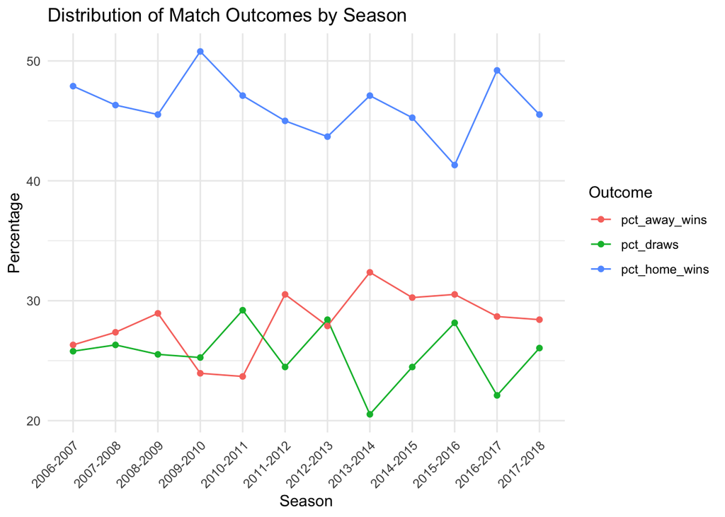

```r
# 1) Keep only the relevant columns and reshape the data to long format
data_summary_long <- data_summary %>%
  select(season, pct_home_wins, pct_draws, pct_away_wins) %>%
  pivot_longer(
    cols = c(pct_home_wins, pct_draws, pct_away_wins),
    names_to = "outcome",
    values_to = "pct"
  )

# 2) Plot as a line chart
ggplot(data_summary_long, aes(x = season, y = pct, color = outcome, group = outcome)) +
  geom_line() +
  geom_point() +
  labs(
    x = "Season",
    y = "Percentage",
    color = "Outcome",
    title = "Distribution of Match Outcomes by Season"
  ) +
  theme_minimal() +
  theme(
    axis.text.x = element_text(angle = 45, hjust = 1)  # tilt labels if needed
  )
```

Interpretation: We clearly see that the home team wins far more games then the away team. This counts for every season. With this analysis, we lay the basis that the home advantage is indeed correct and we can go further and try to find out, if the home advantage gets bigger, the bigger the attendance is for a game.

## Grouped analysis by attendancies

```r
data %>%
  mutate(
    attendance_group = case_when(
      home_average_attendance < 25000 ~ "<25k",
      home_average_attendance < 35000 ~ "25k-35k",
      home_average_attendance < 50000 ~ "35k-50k",
      TRUE                            ~ ">50k"
    )
  ) %>%
  group_by(attendance_group) %>%
  summarise(
    total_matches = n(),
    avg_goal_diff = mean(home_goals - away_goals, na.rm = TRUE),
    pct_home_wins = mean(result == "H", na.rm = TRUE) * 100
  )
```

```
## # A tibble: 4 × 4
##   attendance_group total_matches avg_goal_diff pct_home_wins
##   <chr>                    <int>         <dbl>         <dbl>
## 1 25k-35k                   1216        0.0863          38.6
## 2 35k-50k                   1387        0.776           53.5
## 3 <25k                      1235       -0.121           35.4
## 4 >50k                       722        1.09            63.7
```

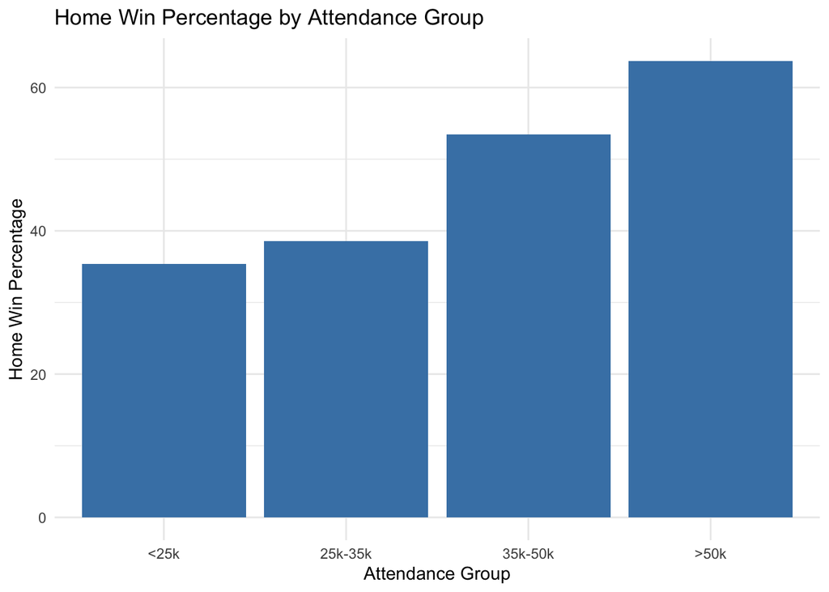

```r
# Create 'attendance_group', reorder its levels, summarize, and store results in 'data_summary'
data_summary <- data %>%
  mutate(
    attendance_group = case_when(
      home_average_attendance < 25000 ~ "<25k",
      home_average_attendance < 35000 ~ "25k-35k",
      home_average_attendance < 50000 ~ "35k-50k",
      TRUE                            ~ ">50k"
    )
  ) %>%
  # Reorder factor levels so they appear in the desired sequence
  mutate(
    attendance_group = factor(
      attendance_group,
      levels = c("<25k", "25k-35k", "35k-50k", ">50k")
    )
  ) %>%
  # Summarize: count total matches, home wins, and compute home-win percentage
  group_by(attendance_group) %>%
  summarise(
    total_matches = n(),
    home_wins     = sum(result == "H", na.rm = TRUE),
    pct_home_wins = 100 * home_wins / total_matches
  )

# Plot a bar chart of home-win percentage by attendance group
ggplot(data_summary, aes(x = attendance_group, y = pct_home_wins)) +
  geom_col(fill = "steelblue") +
  labs(
    x = "Attendance Group",
    y = "Home Win Percentage",
    title = "Home Win Percentage by Attendance Group"
  ) +
  theme_minimal()
```

Interpretation: We grouped the attendances for all the games into these four groupes and calculated the mean home_game_win_percentage for every group. Clearly, we see a trend, that the win percentage gets bigger, with more people in the stadium. But we have to be careful, because we have a confounder. The confounder is that the best teams (this counts for most if not every country) have the biggest stadiums (bigger fanbase etc.). Therefore its no surprise that the play in front of bigger crowds and do also win more games at home.

## Correlation between goals/points with attendance

```r
# Correlation between goals with attendance
cor(data$home_goals - data$away_goals, data$home_average_attendance, use = "complete.obs")
```

```
## [1] 0.2605112
```

```r
# Correlation between points with attendance
cor(data$points_home, data$home_average_attendance, use = "complete.obs")
```

```
## [1] 0.2291079
```

Interpretation: We calculated a correlation between goals with attendance of 0.26 and points with attendance of 0.23. Therefore we have a small correlation between those three variables.

## look for teams whos attendance changed drastically

```r
df_changes <- data %>%
  # 1) Group by team
  group_by(home_team) %>%
  # 2) Sort by season within each team
  arrange(season, .by_group = TRUE) %>%
  # 3) Compute attendance difference & percentage difference
  mutate(
    attendance_diff = home_average_attendance - lag(home_average_attendance),
    attendance_diff_pct = (attendance_diff / lag(home_average_attendance)) * 100
  ) %>%
  # 4) Keep only rows with large (positive or negative) changes
  filter(!is.na(attendance_diff)) %>%  # remove the first row per team (no lag)
  filter(abs(attendance_diff_pct) > 15)

# View the teams/seasons with “drastic” changes
df_changes
```

```
## # A tibble: 4 × 12
## # Groups:   home_team [4]
##   home_team        away_team home_goals away_goals result season goal_difference
##   <chr>            <chr>          <dbl>      <dbl> <chr>  <chr>            <dbl>
## 1 Liverpool        Leiceste…          4          1 H      2016-…               3
## 2 Manchester City  Chelsea            3          0 H      2015-…               3
## 3 Tottenham Hotsp… Chelsea            1          2 A      2017-…              -1
## 4 West Ham United  AFC Bour…          1          0 H      2016-…               1
## # ℹ 5 more variables: points_home <dbl>, points_away <dbl>,
## #   home_average_attendance <dbl>, attendance_diff <dbl>,
## #   attendance_diff_pct <dbl>
```

Interpretation: As we have a confounder, we looked through our dataset to find teams whos season home attendance changed drastically to the next season. We found 4 teams/season in which the attendance changed at least 15% (more or less). Then we did a difference-in-difference analysis, to see whether the bigger/smaller attendance could have an impact on the goal-difference of the home team.

## Difference in difference

### Tottenham Hotspurs

```r
data_spurs <- data %>%
  filter(season %in% c("2015-2016", "2016-2017", "2017-2018"))

data_spurs <- data_spurs %>%
  mutate(
    treat = if_else(home_team == "Tottenham Hotspur" | away_team == "Tottenham Hotspur", 1, 0),
    post  = if_else(season == "2017-2018", 1, 0)
  )

did_mod <- lm((home_goals - away_goals) ~ treat + post + treat:post, data = data_spurs)
summary(did_mod)
```

```
##
## Call:
## lm(formula = (home_goals - away_goals) ~ treat + post + treat:post,
##     data = data_spurs)
##
## Residuals:
##     Min      1Q  Median      3Q     Max
## -6.3977 -1.3450 -0.3450  0.7368  4.7105
##
## Coefficients:
##             Estimate Std. Error t value Pr(>|t|)
## (Intercept)  0.34503    0.07053   4.892 1.14e-06 ***
## treat       -0.05556    0.22304  -0.249    0.803
## post         0.05263    0.12216   0.431    0.667
## treat:post  -0.07895    0.38632  -0.204    0.838
## ---
## Signif. codes:  0 '***' 0.001 '**' 0.01 '*' 0.05 '.' 0.1 ' ' 1
##
## Residual standard error: 1.845 on 1136 degrees of freedom
## Multiple R-squared:  0.0003457,  Adjusted R-squared:  -0.002294
## F-statistic: 0.131 on 3 and 1136 DF,  p-value: 0.9417
```

### Liverpool

```r
data_liv <- data %>%
  # Keep only the four relevant seasons
  filter(season %in% c("2014-2015", "2015-2016", "2016-2017", "2017-2018")) %>%

  # Mark Liverpool as treated (either as home team or away team if you want both),
  # but here we'll mirror the earlier approach and only mark "home_team" == "Liverpool".
  mutate(
    treat = if_else(home_team == "Liverpool", 1, 0),

    # post = 1 for 2016-17 and 2017-18 (the period after the attendance jump),
    # 0 for 2014-15 and 2015-16
    post = if_else(season %in% c("2016-2017", "2017-2018"), 1, 0),

    # Our outcome variable: goal difference from the home team's perspective
    goal_diff = home_goals - away_goals
  )

did_mod_liv <- lm(goal_diff ~ treat + post + treat:post, data = data_liv)
summary(did_mod_liv)
```

```
##
## Call:
## lm(formula = goal_diff ~ treat + post + treat:post, data = data_liv)
##
## Residuals:
##     Min      1Q  Median      3Q     Max
## -6.3241 -1.3213 -0.3213  0.6787  7.6787
##
## Coefficients:
##             Estimate Std. Error t value Pr(>|t|)
## (Intercept)  0.32133    0.06672   4.816 1.61e-06 ***
## treat        0.23130    0.29836   0.775   0.4383
## post         0.00277    0.09435   0.029   0.9766
## treat:post   1.07618    0.42195   2.550   0.0109 *
## ---
## Signif. codes:  0 '***' 0.001 '**' 0.01 '*' 0.05 '.' 0.1 ' ' 1
##
## Residual standard error: 1.793 on 1516 degrees of freedom
## Multiple R-squared:  0.01314,    Adjusted R-squared:  0.01119
## F-statistic: 6.728 on 3 and 1516 DF,  p-value: 0.0001652
```

### Man City

```r
data_mc <- data %>%
  # Keep only the two seasons of interest
  filter(season %in% c("2014-2015", "2015-2016")) %>%
  mutate(
    treat = if_else(home_team == "Manchester City", 1, 0),
    post  = if_else(season == "2015-2016", 1, 0),
    goal_diff = home_goals - away_goals
  )

did_mod_mc <- lm(goal_diff ~ treat + post + treat:post, data = data_mc)
summary(did_mod_mc)
```

```
##
## Call:
## lm(formula = goal_diff ~ treat + post + treat:post, data = data_mc)
##
## Residuals:
##     Min      1Q  Median      3Q     Max
## -6.2271 -1.2271 -0.2271  0.7729  7.6814
##
## Coefficients:
##             Estimate Std. Error t value Pr(>|t|)
## (Intercept)  0.31856    0.08857   3.597 0.000343 ***
## treat        1.26039    0.39608   3.182 0.001522 **
## post        -0.09141    0.12525  -0.730 0.465723
## treat:post  -0.11911    0.56015  -0.213 0.831660
## ---
## Signif. codes:  0 '***' 0.001 '**' 0.01 '*' 0.05 '.' 0.1 ' ' 1
##
## Residual standard error: 1.683 on 756 degrees of freedom
## Multiple R-squared:  0.0246, Adjusted R-squared:  0.02073
## F-statistic: 6.355 on 3 and 756 DF,  p-value: 0.000295
```

### West Ham

```r
data_wh <- data %>%
  # 1) Filter for the relevant seasons
  filter(season %in% c("2014-2015", "2015-2016", "2016-2017", "2017-2018")) %>%

  # 2) Create treat, post, and the outcome variable
  mutate(
    treat = if_else(home_team == "West Ham United", 1, 0),
    post  = if_else(season %in% c("2016-2017", "2017-2018"), 1, 0),
    goal_diff = home_goals - away_goals
  )

did_mod_wh <- lm(goal_diff ~ treat + post + treat:post, data = data_wh)
summary(did_mod_wh)
```

```
##
## Call:
## lm(formula = goal_diff ~ treat + post + treat:post, data = data_wh)
##
## Residuals:
##     Min      1Q  Median      3Q     Max
## -6.4294 -1.3296 -0.3296  1.3684  7.6704
##
## Coefficients:
##             Estimate Std. Error t value Pr(>|t|)
## (Intercept)  0.32964    0.06699   4.921 9.57e-07 ***
## treat        0.06510    0.29960   0.217   0.8280
## post         0.09972    0.09474   1.053   0.2927
## treat:post  -0.86288    0.42370  -2.037   0.0419 *
## ---
## Signif. codes:  0 '***' 0.001 '**' 0.01 '*' 0.05 '.' 0.1 ' ' 1
##
## Residual standard error: 1.8 on 1516 degrees of freedom
## Multiple R-squared:  0.004932,   Adjusted R-squared:  0.002962
## F-statistic: 2.504 on 3 and 1516 DF,  p-value: 0.05763
```

Interpretation of difference-in-difference: For two teams we found a significant impact on attendance on the average goal-difference and for the other two teams we did not. Therefore its hard to say, wether we can clearly state that the bigger home crowd gets those teams an advantage or not.

## Attendancies for these 4 teams

```r
# Define the teams and seasons of interest
teams_of_interest <- c("Tottenham Hotspur", "Liverpool",
                       "Manchester City", "West Ham United")
seasons_of_interest <- c("2013-2014", "2014-2015", "2015-2016",
                         "2016-2017", "2017-2018")

# 1) Filter to the teams & seasons you want
# 2) Group by season & home_team
# 3) Summarize average attendance (ignoring NA values)
# 4) Pivot wider so each team is a separate column
# 5) Arrange by season for a nice chronological table
attendance_summary <- data %>%
  filter(home_team %in% teams_of_interest,
         season %in% seasons_of_interest) %>%
  group_by(season, home_team) %>%
  summarise(avg_home_attendance = mean(home_average_attendance, na.rm = TRUE),
            .groups = "drop") %>%
  pivot_wider(names_from = home_team, values_from = avg_home_attendance) %>%
  arrange(season)

attendance_summary
```

```
## # A tibble: 5 × 5
##   season    Liverpool `Manchester City` `Tottenham Hotspur` `West Ham United`
##   <chr>         <dbl>             <dbl>               <dbl>             <dbl>
## 1 2013-2014     44671             47080               35808             34197
## 2 2014-2015     44659             45365               35728             34871
## 3 2015-2016     43910             54041               35776             34910
## 4 2016-2017     53016             54019               31639             56972
## 5 2017-2018     53049             54070               68052             56885
```

Interpretation: Here I just wanted to have a table, which I can copy on the presentation, for which we see how and when the attendance changes.

## Conclusion

Our analysis suggests that playing at home does indeed confer a measurable advantage, supporting the long-held notion of “home field advantage.” However, we cannot attribute this effect solely to higher attendance or fan support, as many other variables are likely at play. Furthermore, predicting a team’s chance of winning in sports remains challenging due to the multitude of factors—both on and off the field—that can influence a match outcome. To achieve a more precise estimation of winning probabilities, additional features would need to be incorporated into the model, such as measures of each team’s season-long strength. Yet even that alone poses its own challenges, given how difficult it can be to define and quantify a team’s true “strength” over time.